# Econ 8803 PS1

## Rohit Borah & Ping Yang | February 2, 2026

### Load requisite packages.

```r
library(tidyverse)
library(ggthemes)
library(gt)
library(stargazer)
options(scipen = 10)
options(digits = 3)
```

### Question 1: National Supported Work Demonstration

```r
## Import and manipulate data.

df_jtrain2 <-
  as.data.frame(
    read_csv(
      "~/Documents/PhD/Spring 2026/8803 EDA/Problem Sets/PS1/Data/JTRAIN2.csv",
      show_col_types = FALSE
    )
  )
df_jtrain2 <- df_jtrain2 %>%
  mutate(id = row_number()) %>%
  select(id, everything())
```

##### (a) Run a regression of the outcome (earnings in 1978 in $1000s) on the training dummy, linearly controlling for age, marriage status, and earnings in 1974. Report the coefficients and standard errors with 3 significant digits. Provide an interpretation of the coefficient of the treatment dummy.

```r
lm_1a <- lm(re78 ~ train + age + married + re74,
            data = df_jtrain2)

summary(lm_1a)
```

```
##
## Call:
## lm(formula = re78 ~ train + age + married + re74, data = df_jtrain2)
##
## Residuals:
##    Min     1Q Median     3Q    Max
##  -8.18  -4.47  -1.76   2.80  54.09
##
## Coefficients:
##             Estimate Std. Error t value Pr(>|t|)
## (Intercept)   3.1643     1.1873    2.67   0.0080 **
## train         1.7578     0.6331    2.78   0.0057 **
## age           0.0462     0.0450    1.03   0.3047
## married       0.0721     0.8606    0.08   0.9332
## re74          0.1051     0.0588    1.79   0.0743 .
## ---
## Signif. codes:  0 '***' 0.001 '**' 0.01 '*' 0.05 '.' 0.1 ' ' 1
##
## Residual standard error: 6.57 on 440 degrees of freedom
## Multiple R-squared:  0.0277, Adjusted R-squared:  0.0188
## F-statistic: 3.13 on 4 and 440 DF,  p-value: 0.0147
```

```r
# stargazer(lm_1a, title = "Regression 1a", align = TRUE) # Latex table generator
```

##### (b) Verify that you get the same result for $\hat\beta$ if you first run $Y_i$ and the treatment dummy $D_i$ on other covariates, take residuals, and then run the residuals from $Y_i$ regression on the residuals from the $D_i$ regression.

```r
### Run regressions
lm_1by <- lm(re78 ~ age + married + re74,
             data = df_jtrain2)
lm_1bd <- lm(train ~ age + married + re74,
             data = df_jtrain2)

### Store residuals
lm_1by_residuals <- residuals(lm_1by)
lm_1bd_residuals <- residuals(lm_1bd)


### Regress y_residuals on d_residuals
lm_residuals <- lm(lm_1by_residuals ~ lm_1bd_residuals)

summary(lm_residuals)
```

```
##
## Call:
## lm(formula = lm_1by_residuals ~ lm_1bd_residuals)
##
## Residuals:
##    Min     1Q Median     3Q    Max
##  -8.18  -4.47  -1.76   2.80  54.09
##
## Coefficients:
##                  Estimate Std. Error t value Pr(>|t|)
## (Intercept)      8.21e-17   3.10e-01    0.00   1.0000
## lm_1bd_residuals 1.76e+00   6.31e-01    2.79   0.0056 **
## ---
## Signif. codes:  0 '***' 0.001 '**' 0.01 '*' 0.05 '.' 0.1 ' ' 1
##
## Residual standard error: 6.55 on 443 degrees of freedom
## Multiple R-squared:  0.0172, Adjusted R-squared:  0.015
## F-statistic: 7.76 on 1 and 443 DF,  p-value: 0.00557
```

```r
# stargazer(lm_residuals)
```

##### (c) Provide an intuitive explanation for why you may get a similar result in (b).

##### (d) Approximate the CEF of earnings with respect to age.

i. Estimate the CEF, $h(.) = \mathbb E[\verb|earnings|_{78} | \verb|age|]$, non-parametrically.

```r
### Note: we did not bin due to the number of observations per integer.
df_di <- df_jtrain2 %>%
  group_by(age) %>%
  summarize(count = n(),
            mean_re78 = mean(re78))

### Note to GD: I used AI to help write the nonparametric estimation code as
### I am unfamiliar with this.
cef <- loess(re78 ~ age,
             data = df_jtrain2)

df_jtrain2$np_cef <- fitted(cef)
```

ii. Approximate the CEF using a linear regression and a quadratic regression of earnings on age.

```r
### Linear regression
lm_dii_linear <- lm(re78 ~ age,
                    data = df_jtrain2)

summary(lm_dii_linear)
```

```
##
## Call:
## lm(formula = re78 ~ age, data = df_jtrain2)
##
## Residuals:
##    Min     1Q Median     3Q    Max
##  -6.62  -5.00  -1.58   2.82  54.87
##
## Coefficients:
##             Estimate Std. Error t value Pr(>|t|)
## (Intercept)   3.9462     1.1671    3.38  0.00079 ***
## age           0.0534     0.0443    1.21  0.22878
## ---
## Signif. codes:  0 '***' 0.001 '**' 0.01 '*' 0.05 '.' 0.1 ' ' 1
##
## Residual standard error: 6.63 on 443 degrees of freedom
## Multiple R-squared:  0.00327,    Adjusted R-squared:  0.00102
## F-statistic: 1.45 on 1 and 443 DF,  p-value: 0.229
```

```r
df_jtrain2$lm_linear <- fitted(lm_dii_linear)

### Quadratic regression
lm_dii_quad <- lm(re78 ~ age + I(age ^ 2),
                  data = df_jtrain2)

summary(lm_dii_quad)
```

```
##
## Call:
## lm(formula = re78 ~ age + I(age^2), data = df_jtrain2)
##
## Residuals:
##    Min     1Q Median     3Q    Max
##  -6.02  -4.94  -1.66   3.02  54.56
##
## Coefficients:
##             Estimate Std. Error t value Pr(>|t|)
## (Intercept)  0.18570    3.73228    0.05     0.96
## age          0.32712    0.26183    1.25     0.21
## I(age^2)    -0.00459    0.00433   -1.06     0.29
##
## Residual standard error: 6.63 on 442 degrees of freedom
## Multiple R-squared:  0.0058, Adjusted R-squared:  0.0013
## F-statistic: 1.29 on 2 and 442 DF,  p-value: 0.277
```

```r
df_jtrain2$lm_quad <- fitted(lm_dii_quad)
```

iii. Plot the non-parametric CEF, linear, and quadratic fits on the scatter plot between earnings and age. Clearly label which curve corresponds to each specification. What do you observe?

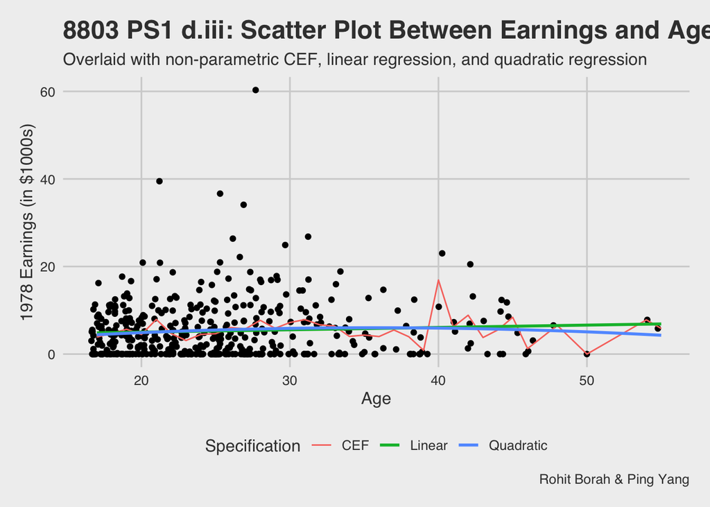

```r
p_1d <- ggplot(data = df_jtrain2,
             aes(x = age,
                 y = re78)) +
  geom_jitter() +
  geom_line(data = df_di,
              aes(x = age,
                  y = mean_re78,
                  color = "CEF"),
              se = FALSE) +
  geom_smooth(
    aes(color = "Linear"),
    method = "lm",
    formula = y ~ x,
    se = FALSE
  ) +
  geom_smooth(
    aes(color = "Quadratic"),
    method = "lm",
    formula = y ~ x + I(x ^ 2),
    se = FALSE
  ) +
  theme_fivethirtyeight() +
  labs(
    title = "8803 PS1 d.iii: Scatter Plot Between Earnings and Age",
    subtitle = "Overlaid with non-parametric CEF, linear regression, and quadratic regression",
    caption = "Rohit Borah & Ping Yang",
    x = "Age",
    y = "1978 Earnings (in $1000s)",
    color = "Specification"
  ) +
  theme(legend.position = "bottom",
        axis.title = element_text())
p_1d
```

iv. Now, using non-parametric CEF as the proxy of true CEF, calculate the mean square error of linear and quadratic fits. Which specification provides a better approximation and why?

```r
mse_linear <- mean((df_jtrain2$np_cef - df_jtrain2$lm_linear) ^ 2)

mse_quad <- mean((df_jtrain2$np_cef - df_jtrain2$lm_quad) ^ 2)
```

##### (e) Now focus on the estimate of the training dummy $\hat\beta$. The estimator can be written as: $\hat\beta = \sum_i\omega_i(\textbf{X})Y_i$ where $\omega_i(\textbf{X})$ are the implicit weights placed on each outcome, which depend on the full regressor matrix **X**. Recover these weights using the following two techniques:

i. Using FWL, derive the expression for these weights: $\omega_i = \frac{\bar D_i}{\sum_j \bar D_j^2}$

where $\bar D_i$ is the residual from regressing the treatment dummy on the controls. Plot the histogram of $\omega_i(\textbf{X})$ across all observations.

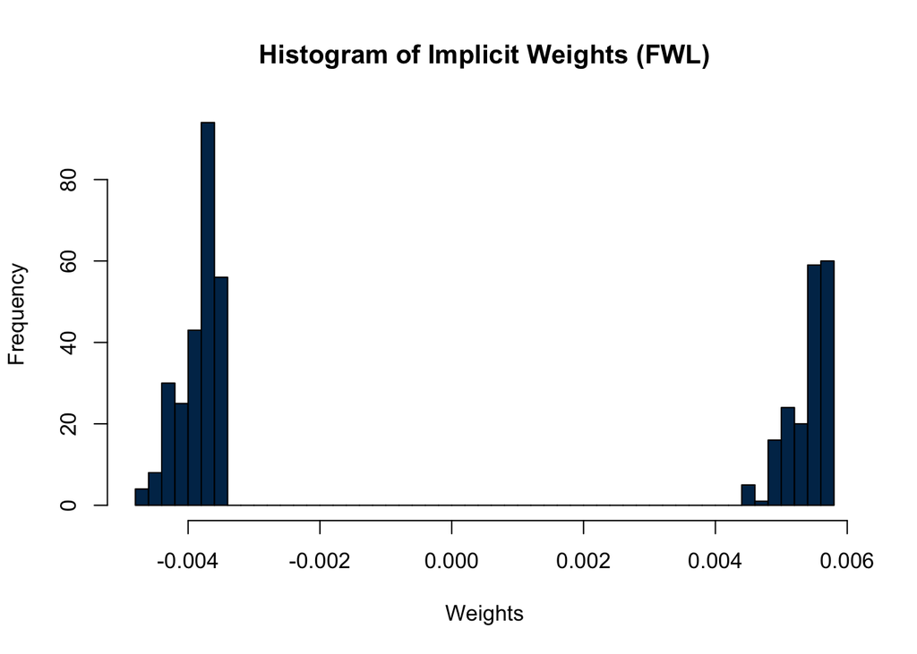

```r
weights_fwl <- lm_1bd_residuals / sum(lm_1bd_residuals^2)

p_1e_fwl_1 <- hist(weights_fwl,
     main = "Histogram of Implicit Weights (FWL)",
     xlab = "Weights",
     col = "#003057",
     breaks = 40)
```

```r
p_1e_fwl_1
```

[output not shown]

ii. Using the matrix formula $\hat\beta = (X'X)^{-1}X'Y$, compute the weights directly. Plot the histogram of $\omega_i(\textbf{X})$ across all observations. Is it similar to part (i)?

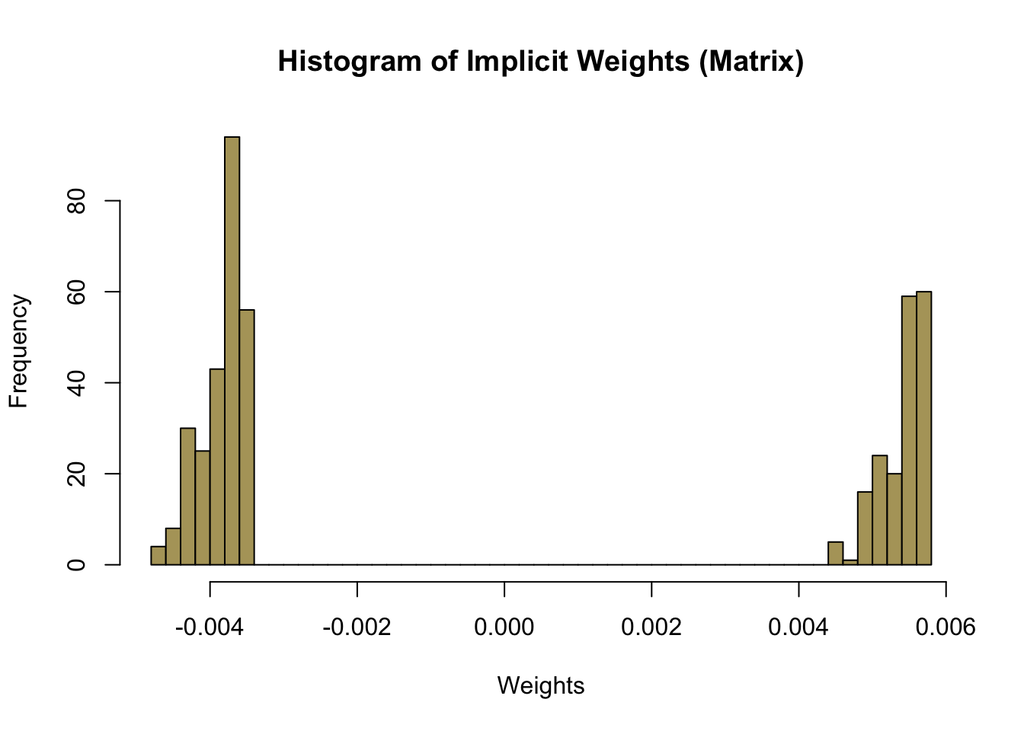

```r
matrix_1e_1 <- model.matrix(~ train + age + married + re74,
                               data = df_jtrain2)

matrix_1e_2 <- solve(t(matrix_1e_1) %*% matrix_1e_1) %*% t(matrix_1e_1)

weights_matrix <-matrix_1e_2[2, ]

p_1e_fwl_2 <- hist(weights_matrix,
     main = "Histogram of Implicit Weights (Matrix)",
     xlab = "Weights",
     col = "#B3A369",
     breaks = 40)
```

```r
p_1e_fwl_2
```

[output not shown]

iii. Intuitively, what does the variation in these weights tell you about the identification of the treatment indicator?

### Question 2: Nicaragua

```r
## Import and manipulate data.
df_n <-
  read_csv(
    "~/Documents/PhD/Spring 2026/8803 EDA/Problem Sets/PS1/Data/Nicaragua_RCT.csv",
    ,
    show_col_types = FALSE
  )

variables <-
  c(
    "complier",
    "income_r1",
    "income_r2",
    "rubro",
    "age",
    "education",
    "mobcap",
    "fixcap",
    "land"
  )
```

##### (a) Under successful randomization, what would we expect the value of the following expression to be?

$\mathbb E[complier_i | assign_i = 1] - \mathbb E[complier_i | assign_i = 0]$

Compute the sample analogues of the above expression. Use a difference-of-means test to check if the difference is statistically significant. What do you observe?

```r
df_n %>%
  group_by(assign) %>%
  summarize(x_complier = mean(complier))
```

```
## # A tibble: 3 × 2
##   assign x_complier
##    <dbl>      <dbl>
## 1      0      0.696
## 2      1      0.668
## 3     NA     NA
```

```r
t_2a <- t.test(complier ~ assign, data = df_n)
t_2a
```

```
##
##  Welch Two Sample t-test
##
## data:  complier by assign
## t = 1, df = 1256, p-value = 0.3
## alternative hypothesis: true difference in means between group 0 and group 1 is not equal to 0
## 95 percent confidence interval:
##  -0.0236  0.0793
## sample estimates:
## mean in group 0 mean in group 1
##           0.696           0.668
```

##### (b) Under successful randomization, what other variable(s) should be uncorrelated with $\verb|assign|$? Again, comparing sample means among these variables, is there any evidence that treated and control households are unbalanced?

```r
### Create df for E[var|assign = 1]
df_assign_1 <- df_n %>%
  filter(assign == 1) %>%
  summarize(
    complier = mean(complier, na.rm = TRUE),
    income_r1 = mean(income_r1, na.rm = TRUE),
    income_r2 = mean(income_r2, na.rm = TRUE),
    rubro = mean(rubro, na.rm = TRUE),
    age = mean(age, na.rm = TRUE),
    education = mean(education, na.rm = TRUE),
    mobcap = mean(mobcap, na.rm = TRUE),
    fixcap = mean(fixcap, na.rm = TRUE),
    land = mean(land, na.rm = TRUE)
  ) %>%
  pivot_longer(cols = everything(),
               names_to = "variable",
               values_to = "mean_assign_1")

### Create df for E[var|assign = 0]
df_assign_0 <- df_n %>%
  filter(assign == 0) %>%
  summarize(
    complier = mean(complier, na.rm = TRUE),
    income_r1 = mean(income_r1, na.rm = TRUE),
    income_r2 = mean(income_r2, na.rm = TRUE),
    rubro = mean(rubro, na.rm = TRUE),
    age = mean(age, na.rm = TRUE),
    education = mean(education, na.rm = TRUE),
    mobcap = mean(mobcap, na.rm = TRUE),
    fixcap = mean(fixcap, na.rm = TRUE),
    land = mean(land, na.rm = TRUE)
  ) %>%
  pivot_longer(cols = everything(),
               names_to = "variable",
               values_to = "mean_assign_0")

### Run t-tests for each variable.
### Note for GD- this was assisted by AI for speed.

p_values <- sapply(variables, function(v) {
  t.test(df_n[[v]][df_n$assign == 1], df_n[[v]][df_n$assign == 0])$p.value
})

### Create joined df
df_2b <- left_join(df_assign_1, df_assign_0,
                   by = "variable") %>%
  mutate(
    delta = mean_assign_1 - mean_assign_0,
    p_value = p_values,
    sig = ifelse(p_value < 0.05, "Yes", "No")
  )

df_2b %>%
  gt() %>%
  cols_label(
    variable = "Variable",
    mean_assign_1 = "Mean (Treated)",
    mean_assign_0 = "Mean (Control)",
    delta = "Difference",
    p_value = "P-value",
    sig = "Significant"
  ) %>%
  tab_style(
    style = cell_text(weight = "bold"),
    locations = cells_column_labels(columns = everything())
  ) %>%
  fmt_number(decimals = 3)
```

| Variable | Mean (Treated) | Mean (Control) | Difference | P-value | Significant |
| --- | --- | --- | --- | --- | --- |
| complier | 0.668 | 0.696 | −0.028 | 0.288 | No |
| income_r1 | 7,576.573 | 8,795.342 | −1,218.769 | 0.056 | No |
| income_r2 | 10,250.516 | 10,709.649 | −459.133 | 0.584 | No |
| rubro | 1.728 | 1.824 | −0.096 | 0.011 | Yes |
| age | 52.266 | 54.539 | −2.273 | 0.002 | Yes |
| education | 3.926 | 3.968 | −0.042 | 0.861 | No |
| mobcap | 3,916.307 | 3,800.981 | 115.326 | 0.799 | No |
| fixcap | 3,381.100 | 3,514.176 | −133.076 | 0.740 | No |
| land | 37.201 | 47.551 | −10.350 | 0.017 | Yes |

##### (c) We can define the average treatment effect on the treated (ATT), that is the effect of $\verb|treat|$ on $\verb|income|$ among the treated households, using the following linear model:

$income_i = \alpha + \beta_{ATT} \times treat_i + \epsilon_i$

If we estimate this model on the full set of households using OLS, will $\hat\beta$ be an unbiased estimate of $\beta_{ATT}$? Why or why not?

```r
### Comparing baseline income_r1 for compliers vs non-compliers
mean(df_n$income_r1[df_n$complier == 1], na.rm = TRUE)
```

```
## [1] 8718
```

```r
mean(df_n$income_r1[df_n$complier == 0], na.rm = TRUE)
```

```
## [1] 6924
```

##### (d) Now, estimate two sets of specifications for Equation 2, one without any covariates and one with the baseline variables $\verb|rubro, age, education, mobcap, fixcap, land|.$ Provide an interpretation of $\hat\beta_{ATT}$ for both cases. Do they differ? Why or why not?

```r
### Without covariates
lm_2di <- lm(income_r2 ~ treat,
             data = df_n)

summary(lm_2di)
```

```
##
## Call:
## lm(formula = income_r2 ~ treat, data = df_n)
##
## Residuals:
##    Min     1Q Median     3Q    Max
## -11050  -8970  -5374   4222 113620
##
## Coefficients:
##             Estimate Std. Error t value Pr(>|t|)
## (Intercept)    10100        534    18.9   <2e-16 ***
## treat            949        860     1.1     0.27
## ---
## Signif. codes:  0 '***' 0.001 '**' 0.01 '*' 0.05 '.' 0.1 ' ' 1
##
## Residual standard error: 14600 on 1222 degrees of freedom
##   (46 observations deleted due to missingness)
## Multiple R-squared:  0.000995,   Adjusted R-squared:  0.000178
## F-statistic: 1.22 on 1 and 1222 DF,  p-value: 0.27
```

```r
# stargazer(lm_2di)

### With baseline variables
lm_2dii <-
  lm(income_r2 ~ treat + rubro + age + education + mobcap + fixcap + land,
     data = df_n)

summary(lm_2dii)
```

```
##
## Call:
## lm(formula = income_r2 ~ treat + rubro + age + education + mobcap +
##     fixcap + land, data = df_n)
##
## Residuals:
##    Min     1Q Median     3Q    Max
## -63079  -4497  -2360   2383  94058
##
## Coefficients:
##               Estimate Std. Error t value Pr(>|t|)
## (Intercept) -2400.3934  1936.6024   -1.24    0.215
## treat        1262.0179   736.4763    1.71    0.087 .
## rubro        3183.5581   562.8527    5.66  1.9e-08 ***
## age            29.2833    29.3152    1.00    0.318
## education     238.3735    96.6945    2.47    0.014 *
## mobcap          0.6026     0.0546   11.03  < 2e-16 ***
## fixcap          0.0521     0.0564    0.92    0.357
## land           42.5096     5.2018    8.17  7.6e-16 ***
## ---
## Signif. codes:  0 '***' 0.001 '**' 0.01 '*' 0.05 '.' 0.1 ' ' 1
##
## Residual standard error: 12300 on 1204 degrees of freedom
##   (58 observations deleted due to missingness)
## Multiple R-squared:  0.276,  Adjusted R-squared:  0.271
## F-statistic: 65.5 on 7 and 1204 DF,  p-value: <2e-16
```

```r
# stargazer(lm_2dii)
```